# Trabalho Pares 1 [Modelação Estocástica]

André Silvestre Nº104532 | Margarida Pereira Nº105877

2023-10-10

# Exercício 1

Pretende-se que gere 10.000 números pseudo-aleatórios provenientes da distribuição triangular:

1. Recorra ao método da aceitação-rejeição.
2. Crie uma função de raiz para definir a distribuição triangular. Note que a distribuição triangular é definida por três parâmetros: *$min$*, o vértice inferior esquerdo do triângulo, *$max$*, o vértice inferior direito, e *$mode$*, o vértice superior. A escolha de valores para os parâmetros é discricionária.
3. Os resultados devem ser apresentados em `matrix` ou `data.frame`, para além de um *output* gráfico simples que permita visualizar a densidade aproximada dos números simulados.

## Resolução

Para a resolução deste problema, verificámos que a **distribuição triangular** [[1]](https://pt.wikipedia.org/wiki/Distribui%C3%A7%C3%A3o_triangular) pode ser parametrizada por $a$, $b$ e $c$, que são o vértice inferior esquerdo (também designado por $min$), o vértice inferior direito ($max$) e o vértice superior (centro - $mode$ ) do triângulo, respectivamente.

Por definição, a função densidade de probabilidade (f.d.p.) desta distribuição é dada por:

$$f(x | a, b, c)= \begin{cases}0 &
x<a \\ \frac{2(x-a)}{(b-a)(c-a)} & a \leq x<c \\ \frac{2}{b-a}
& x=c \\ \frac{2(b-x)}{(b-a)(b-c)} & c<x \leq b \\ 0 &
x>b\end{cases}$$

```r
# a) Método da Aceitação-Rejeição - Considerámos g(x) como a Normal(2, 0.75)

require(EnvStats)    # Biblioteca com a função da distribuição triangular
require(ggplot2)     # Gráficos
require(ggfortify)
require(ggtext)

fx <- function(x){
  # Programar a f.d.p de f(x) - dist. da qual desejamos simular
  # Neste caso, vamos considerar a f.d.p. da dist. triangular com min = 0, mode = 2 e max = 4
  new_x <- dtri(x, min = 0, max= 4, mode = 2)
  return(new_x)
}
```

> A distribuição normal, escolhida para $g(x)$, para satisfazer a condição $c \times g(x) ≥ f(x)$ deverá ser multiplicada pelo máximo de $\frac{f(x)}{g(x)}$

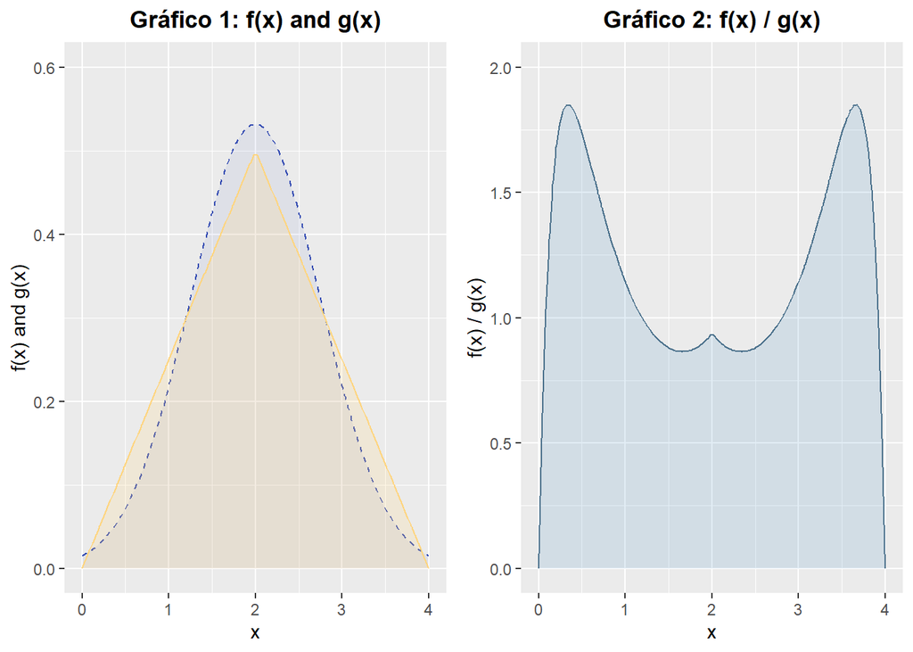

```r
# Crie uma sequência de valores para x e calcular os y da f.d.p. de f(x) e g(x)
x <- seq(0, 4, length.out = 100)
dt <- dtri(x, min = 0, max = 4, mode = 2)
dn <- dnorm(x, mean = 2, sd = .75)
df <- data.frame(x = x, dt = dt, dn = dn)

# Gráfico 1 - f(x) e g(x)
g1 <- ggplot(df, aes(x = x)) +
  geom_area(aes(y = dn), fill="#324ab2", color = "#324ab2", linetype = "dashed", alpha = .07) +
  geom_area(aes(y = dt), fill="#FFD580", color = "#FFD580", alpha = .2) + ylim(0, .6) +
  labs(title = "Gráfico 1: f(x) and g(x)", y = "f(x) and g(x)") +
  theme(plot.title = element_markdown(hjust = 0.5, face = "bold"))

# Gráfico 2 - f(x)/g(x)
g2 <- ggplot(df, aes(x = x)) + ylim(0, 2) +
  geom_area(aes(y = dt/dn), fill="skyblue3", color = "skyblue4", alpha = .2) +
  labs(title = "Gráfico 2: f(x) / g(x)", y = "f(x) / g(x)") +
  theme(plot.title = element_markdown(hjust = 0.5, face = "bold"))

# Organizar os gráficos lado a lado
library(gridExtra)
grid.arrange(g1, g2, ncol = 2)
```

Como $c$ - *Constante de Rejeição* é definida por:

$$c = sup \;
\frac{f(x)}{g(x)}$$

Determinámos o valor máximo do quociente entre $f(x)$ e $g(x)$

```r
# Encontrar o valor máximo
foo <- function(x) dtri(x, min = 0, max = 4, mode = 2)/dnorm(x, mean = 2, sd = .75)
opt <- optimize(foo, c(0,4), maximum = TRUE)
c <- opt$objective
paste("Valor Ótimo de c =",round(c,2))
```

```
## [1] "Valor Ótimo de c = 1.85"
```

```r
# ================= Algoritmo do Método da Aceitação-Rejeição =================

set.seed(2023)    # Para permitir reprodutibilidade

k = 0             # Estabelece um contador para o número de observações aceites
count = 1         # Estabelece um contador para o número de iterações percorridas
accept = c()      # Cria um vector vazio onde iremos guardar as simulações, x, aceites

# Percorrer o algoritmo até atingir os 10 000 NPAs gerados
while(k < 10000){

  # Gerar x da distribuição g(x) proposta - N(2, 0.75)
  X <- rnorm(1, mean = 2, sd = .75)

  # Gerar um u da distribuição Uniforme(0,1)
  U_sim <- runif(1, 0, 1)

  # Calcular o valor de f(x)/cg(x)
  cg_x <- fx(X)/(c*dnorm(X, mean = 2 , sd = .75))

  # Comparar os dois valores - Aceita-se ou Rejeita-se
  if(U_sim <= cg_x){

    # Se o valor proveniente da U(0,1) for inferior a cg(x), então:
    # Aceitar a simulação acrescentando uma linha ao vector 'accept'
    accept = rbind(accept, X)
    k = k + 1
  }

  # Caso contrário, descartar a simulação, aumentar o contador em 1, e
  #                 seguir para a próxima iteração
  count = count + 1
}

paste("Nº de Iterações",count-1)
```

```
## [1] "Nº de Iterações 18572"
```

```r
paste("Nº de Valores 'y' Aceites",length(accept))
```

```
## [1] "Nº de Valores 'y' Aceites 10000"
```

Foram necessárias **$18 572$** iterações para obter $10000$ observações do modelo $Triangular(min=0, max=4, mode=2)$. Esperavam-se obter $c \times n = 1.850733 \times 10 000 = 18 507$ iterações.

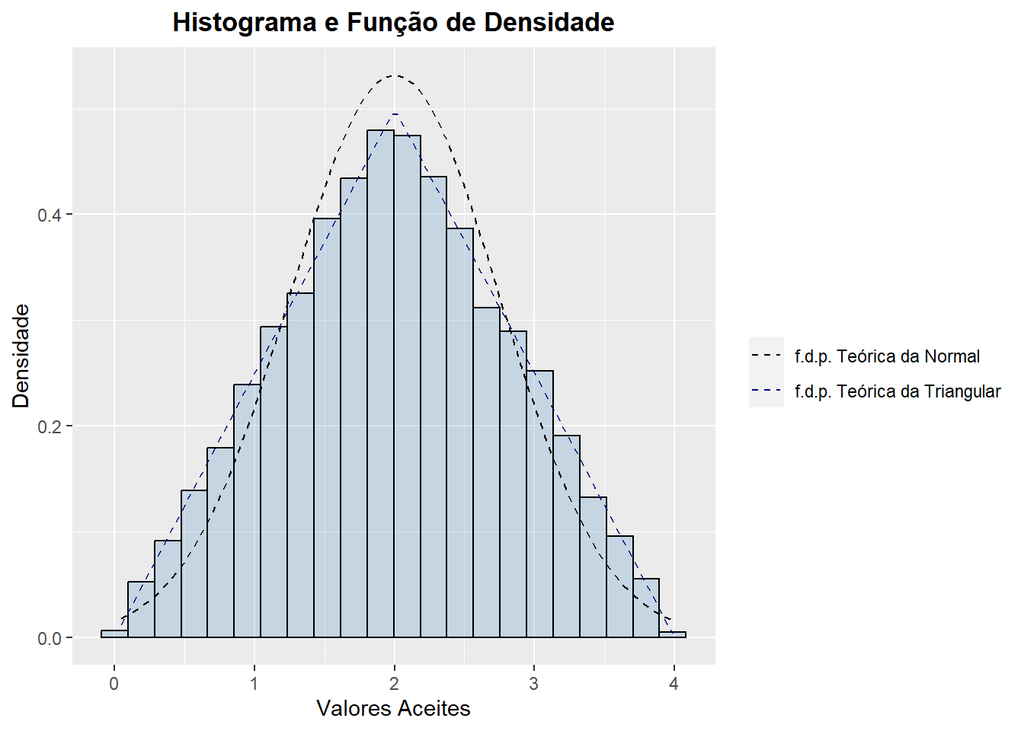

```r
#Inspecção visual da amostra gerada
ggplot(data.frame(accept), aes(x=accept)) +

  # Histograma dos valores gerados
  geom_histogram(aes (y= after_stat(density)), binwidth=0.19,
                 color="black", fill="skyblue3", alpha = 0.3) +

  # Adiciona linha da função de distribuição normal teórica
  geom_line(stat = "function", fun = function(x) dnorm(x = x, mean = 2, sd = .75),
            aes(col = "f.d.p. Teórica da Normal"), linetype = "dashed") +

  # Adiciona linha da função de distribuição triangular teórica
  geom_line(stat = "function", fun = function(x) dtri(x, min = 0, max= 4, mode = 2),
            aes(col = "f.d.p. Teórica da Triangular"), linetype = "dashed", ) +

  # Adiciona as legendas
  scale_color_manual(name = "",
                     values = c("f.d.p. Teórica da Normal" = "black", "f.d.p. Teórica da Triangular" = "#000080"),
                     guide = guide_legend(override.aes = list(linetype = "dashed"))) +

  theme(plot.title = element_markdown(hjust = 0.5, face = "bold")) +
  ggtitle("Histograma e Função de Densidade") +
  labs(x = "Valores Aceites", y = "Densidade")
```

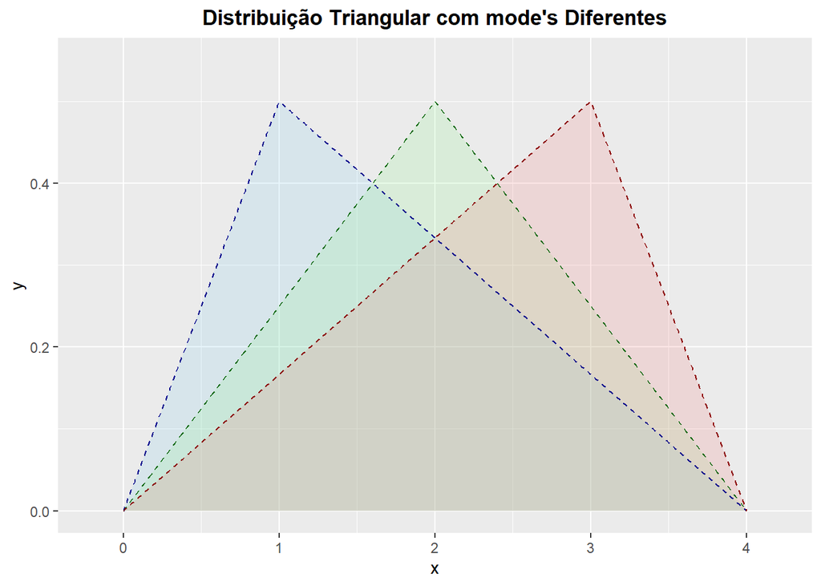

```r
# b) Função Raiz da Distribuição Triangular e análise de casos particulares com paramtrizações escolhidas

dtriangular <- function(x, min, mode, max) {
  if (x <= min || x >= max) {
    return(0)
  } else if (x <= mode) {
    return(2 * (x - min) / ((max - min) * (mode - min)))
  } else {
    return(2 * (max - x) / ((max - min) * (max - mode)))
  }
}

# Parâmetros das distribuição triangulares - mantendo o mesmo min e máx
min_value <- 0
max_value <- 4

mode_value1 <- 1
mode_value2 <- 2
mode_value3 <- 3

# Vetor de valores de x
x <- seq(0, 4, .01)

# Valores para as três distribuições
y1 <- sapply(x, function(xi) dtriangular(xi, min_value, mode_value1, max_value))
y2 <- sapply(x, function(xi) dtriangular(xi, min_value, mode_value2, max_value))
y3 <- sapply(x, function(xi) dtriangular(xi, min_value, mode_value3, max_value))

# Gráfico
df <- data.frame(x = x, y = c(y1, y2, y3), group = c("dt1", "dt2", "dt3"))

# Gráfico
ggplot() +
  geom_area(aes(x = x, y = y1), fill = "skyblue", alpha = 0.2, linetype = 2 ) +
  geom_area(aes(x = x, y = y2), fill = "lightgreen", alpha = 0.2, linetype = 2) +
  geom_area(aes(x = x, y = y3), fill = "lightcoral", alpha = 0.2, linetype = 2) +

  geom_line(aes(x = x, y = y1), linetype = "dashed", color = "darkblue") +
  geom_line(aes(x = x, y = y2), linetype = "dashed", color = "darkgreen") +
  geom_line(aes(x = x, y = y3), linetype = "dashed", color = "darkred") +

  labs(title = "Distribuição Triangular com mode's Diferentes",x = "x", y = "y") +
  theme(legend.position = "top") + ylim(0,.55) + xlim(-0.2, 4.2) +
  theme(plot.title = element_text(hjust = 0.5, face = "bold"))
```

```r
# c) Resultados

# Comparação pontualmente dos percentis empíricos com os percentis teóricos
p <- seq(.1, .9, .1)
Qhat <- quantile(accept, p)                    # Quantis da Amostra Gerada
Q <-   qtri(p, min = 0, max = 4, mode = 2)     # Quantis Teóricos da dist. Triangular
round(rbind(Qhat, Q), 3)
```

```
##        10%   20%   30%   40%   50%   60%   70%   80%   90%
## Qhat 0.904 1.268 1.546 1.787 1.993 2.207 2.445 2.738 3.099
## Q    0.894 1.265 1.549 1.789 2.000 2.211 2.451 2.735 3.106
```

```r
# accept # Valores gerados
```

# Exercício 2

Pretende-se que realize um estudo comparativo de dois estimadores para o coeficiente de assimetria de distribuições de probabilidade. Considere os estimadores $s_1$ e $s_2$ para a assimetria de uma população qualquer:

$$s_1=\frac{Q_3+Q_1-2
Q_2}{Q_3-Q_1}$$

$$s_2=\frac{(\mu-\nu)}{E(|X-\nu|)}$$

em que, na Equação 1, $Q_i$ representa o quartil respectivo e, na Equação 2, $\mu$ corresponde à média e $ν$ corresponde à mediana.

1. Gere, utilizando o gerador base do R para a distribuição *t-student* (`rt()`), e com `set.seed(2023)`:
1. $100$ amostras de dimensão $n = 20$
2. $100$ amostras de dimensão $n = 100$
3. $100$ amostras de dimensão $n = 1000$
2. Obtenha, para cada amostra gerada e para cada estimador, a assimetria amostral (estimativa) correspondente.
3. Recorrendo ao cálculo do erro-padrão e do erro quadrático médio, conclua pela sua preferência por um dos esti- madores e comente o seu comportamento, em função da dimensão das amostras obtidas. Apresente os resultados num `data.frame`.

## Resolução

```r
# a) Geração das 100 Amostras (n=20, n=100, n=1000 | df=20 (Escolha discricionária))

# Definir a semente para reprodutibilidade
set.seed(2023)

# Gerar as Amostras - matriz n x 100
sample_20 <- replicate(100, rt(20, df = 20))
sample_100 <- replicate(100, rt(100, df = 20))
sample_1000 <- replicate(100, rt(1000, df = 20))
```

```r
# b) Assimetria Amostral (estimativa) para cada amostra

# Função para calcular s1 - Estimativa da Assimetria Amostral 1
s1_estimator <- function(X) {
  Q1 <- quantile(X, 0.25)
  Q2 <- median(X)
  Q3 <- quantile(X, 0.75)
  return ((Q3 + Q1 - 2 * Q2) / (Q3 - Q1))
}

# Função para calcular s2 - Estimativa da Assimetria Amostral 2
s2_estimator <- function(X) {
  mediana <- median(X)
  media <- mean(X)
  return ((media - mediana) / mean(abs(X - mediana)))
}

# Calcular s1 e s2 para cada amostra de 20 observações
s1_values_20 <- apply(sample_20,
                      MARGIN = 2,         # MARGIN = 2 indica que a função será aplicada nas colunas
                      FUN = s1_estimator) # FUN = função que queremos aplicar
s2_values_20 <- apply(sample_20, 2, s2_estimator)

# Calcular s1 e s2 para cada amostra de 100 observações
s1_values_100 <- apply(sample_100, 2, s1_estimator)
s2_values_100 <- apply(sample_100, 2, s2_estimator)

# Calcular s1 e s2 para cada amostra de 1000 observações
s1_values_1000 <- apply(sample_1000, 2, s1_estimator)
s2_values_1000 <- apply(sample_1000, 2, s2_estimator)
```

Dado que a distribuição gerada é a *t-student* e, na população, esta distribuição é simétrica, era de esperar que $skewness = 0$, pelo que iremos considerar este valor como `true value` no cálculo do **MSE**.

```r
# c) Cálculo do Erro-Padrão e do Erro Quadrático Médio (MSE) e Conclusões

# Calcular Erro-Padrão e Erro Quadrático Médio para s1
se_s1_20 <- sd(s1_values_20) / sqrt(100)
se_s1_100 <- sd(s1_values_100) / sqrt(100)
se_s1_1000 <- sd(s1_values_1000) / sqrt(100)

mse_s1_20 <- mean((s1_values_20 - 0)^2)
mse_s1_100 <- mean((s1_values_100 - 0)^2)
mse_s1_1000 <- mean((s1_values_1000 - 0)^2)

# Calcular erro-padrão e erro quadrático médio para s2
se_s2_20 <- sd(s2_values_20) / sqrt(100)
se_s2_100 <- sd(s2_values_100) / sqrt(100)
se_s2_1000 <- sd(s2_values_1000) / sqrt(100)

mse_s2_20 <- mean((s2_values_20 - 0)^2)
mse_s2_100 <- mean((s2_values_100 - 0)^2)
mse_s2_1000 <- mean((s2_values_1000 - 0)^2)

# Criar um data.frame com os resultados
results_df <- data.frame(
  Sample_Size = rep(c(20, 100, 1000), 2),
  Estimador = c("","s1","","","s2",""),
  SE = round(c(se_s1_20, se_s1_100, se_s1_1000, se_s2_20, se_s2_100, se_s2_1000),4),
  MSE = round(c(mse_s1_20, mse_s1_100, mse_s1_1000, mse_s2_20, mse_s2_100, mse_s2_1000),4)
)
```

```r
require(flextable)
require(magrittr)

# Tabela com os resultados
ftable_1 <- flextable(head(results_df))

ftable_1 <- bg(ftable_1, bg = "#006a4e", part = "header")
ftable_1 <- color(ftable_1, color = "white", part = "header")
ftable_1 <- bold(ftable_1, bold = TRUE, part="header")
ftable_1 <- set_header_labels(ftable_1,Sample_Size = 'n', Estimador = 'Estimador', SE = 'SE', MSE = 'MSE')
ftable_1 <- autofit(ftable_1)
ftable_1 %>%
  mk_par(j = "Estimador",value = as_paragraph(as_chunk(Estimador, props = fp_text_default(bold = TRUE)))) %>%
  hline(i = 3, part = "body") %>%
  hline(i = 6)
```

| n | Estimador | SE | MSE |
| --- | --- | --- | --- |
| 20 |  | 0.0266 | 0.0702 |
| 100 | s1 | 0.0131 | 0.0184 |
| 1,000 |  | 0.0034 | 0.0012 |
| 20 |  | 0.0188 | 0.0350 |
| 100 | s2 | 0.0081 | 0.0069 |
| 1,000 |  | 0.0025 | 0.0006 |

#### Boxplot para mostrar a variação dos estimadores para diferentes $n$ amostras

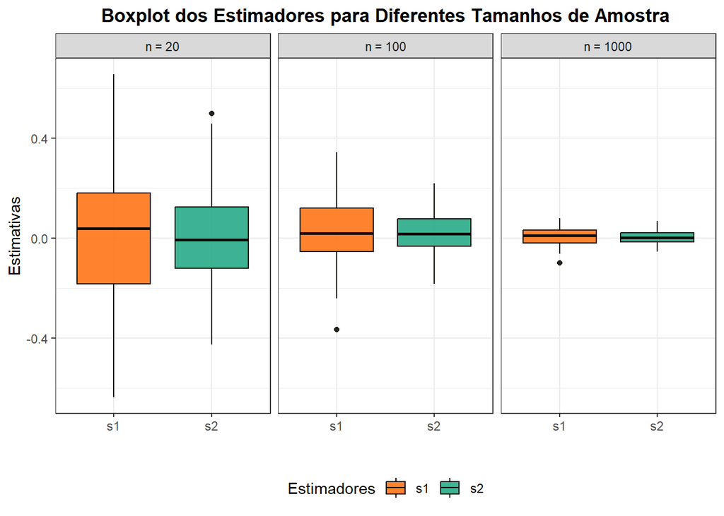

```r
# Combinar os dados num data.frame
s1_combined <- c(s1_values_20, s1_values_100, s1_values_1000)
s2_combined <- c(s2_values_20, s2_values_100, s2_values_1000)
sample_sizes_combined <- rep(c("n = 20", "n = 100", "n = 1000"), each = 100)
estimators_combined <- rep(c("s1", "s2"), each = 300)

s1_s2 <- data.frame(
  Value = c(s1_combined, s2_combined),
  Sample_Size = factor(sample_sizes_combined, levels = c("n = 20", "n = 100", "n = 1000")),
  Estimator = estimators_combined
)

# Boxplot
ggplot(s1_s2, aes(x = Estimator , y = Value, fill = Estimator, color = as.factor(Sample_Size))) +
  geom_boxplot(alpha = .9, color = "#100c08") +
  facet_wrap(.~Sample_Size) +
  scale_fill_manual(values = c("#ff7518", "#29ab87")) +
  labs(title = "Boxplot dos Estimadores para Diferentes Tamanhos de Amostra", x = "", y = "Estimativas") +
  theme_bw() +
  theme(legend.position = "bottom") +
  theme(plot.title = element_text(hjust = 0.5, face = "bold")) +
  guides(fill = guide_legend(title = "Estimadores"))
```